# Who Pushes the Welfare State? Business, Labor, and the Comfortable

POSC 459 — Social Welfare Politics and Policy · Week 14, Wednesday 2 December 2026 (asynchronous week)

*Accessible text version of the Week 14 Wednesday slides — same content in linear order, with no slide-scaling container. Each image carries a text description. Asynchronous week. Readings: Howard (2023), Who Cares, chapter 2, “Business and Labor”; Desmond (2023), Poverty, by America, chapter 6.*

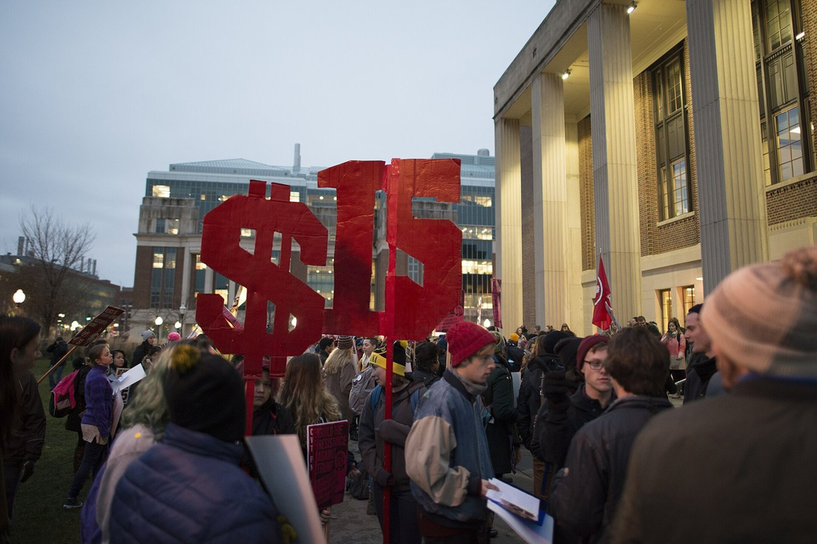

This deck walks you through Howard’s *Who Cares*, chapter 2, and Desmond’s *Poverty, by America*, chapter 6. Monday’s deck covered Howard’s other book.

*Photo: rally for a $15 minimum wage, Minneapolis, November 29, 2016. Fibonacci Blue, CC BY 2.0.*

## This week: no class meetings, one big deadline

1. **Your term paper is due today, Wednesday, December 2, at 11:59 p.m.** Upload a PDF to Canvas: 6–8 pages, double-spaced, APA, at least five new sources.
2. **If you used AI on the paper,** add a one-sentence disclosure or attach your downloaded PapyrusAI conversation.
3. **Read *Who Cares* ch. 2 (Pollak ebook) and Desmond ch. 6** with this deck. Monday’s deck covered Howard, chapters 6 and 7.
4. **There is no discussion paper this week.**
5. **Reading journal:** your last five entries are due Wednesday, December 9.
6. **We meet again Monday, December 7,** in GH 305.

*The final exam is Monday, December 14, 1:00–2:50 p.m., in GH 305. Bring a blue book. Questions this week? Email me.*

## How to use this deck (about 25 minutes)

The deck answers two questions: - *Who Cares*, chapter 2: Do business groups and labor unions speak up for poor people? - **Desmond, chapter 6:** How do better-off Americans keep opportunity for themselves?

Each slide opens with **what happened**, shows the evidence, and ends with a shaded box, **Why it matters**, saying what you should now be able to argue. Boxes marked **Use in your paper** hold claims that fit the term paper.

**Citing these readings:** the library’s copy of *Who Cares* has no book page numbers, so slides name the chapter section; cite the page your Pollak reader shows. Desmond slides give his endnote number, like note [9]; cite the page in your own copy.

## Glossary 1: the groups in this deck

| Group | Who they are |
| --- | --- |
| **AFL-CIO** | The largest federation of U.S. labor unions: more than 50 unions with over 12 million members |
| **SEIU** | Service Employees International Union, about 2 million members, many in low-wage jobs. It left the AFL-CIO in 2005 |
| **AFT, AFSCME** | The American Federation of Teachers and the union of state, county, and city employees. Both belong to the AFL-CIO |
| **NFIB** | National Federation of Independent Business, the main lobby for small-business owners |
| **U.S. Chamber of Commerce** | A business federation, since 1912, of mostly small and midsized firms, with large ones too |
| **Business Roundtable** | The chief executives of the largest U.S. corporations, organized in the early 1970s |
| **American Hospital Association** | The national lobby for hospitals, which Medicaid pays to treat patients |
| **Peak association** | A group that speaks for business (or labor) across many industries. The NFIB, the Chamber, and the Roundtable are business’s |

## Glossary 2: the laws and ideas in this deck

| Term | What it means |
| --- | --- |
| **Minimum wage** | The lowest hourly pay the law allows. The federal minimum was $7.25 in 2019 and had not risen in a decade (*Who Cares*) |
| **Medicaid expansion** | The Affordable Care Act (ACA, 2010) let states cover everyone under 138% of the poverty line. The NFIB’s Supreme Court case, *NFIB v. Sebelius* (2012), made expansion each state’s choice |
| **Social insurance** | Programs you earn by working, open to all income levels: Social Security, Medicare, unemployment insurance |
| **Public assistance** | Programs only for people with low incomes: TANF (cash welfare), SSI, public housing, Medicaid |
| **Proposition 13** | A 1970s California ballot measure that capped property taxes (Desmond, note [12]) |
| **ERTA** | The Economic Recovery Tax Act of 1981, President Reagan’s tax cut (note [11]) |
| **Private opulence, public squalor** | Economist John Kenneth Galbraith’s 1958 phrase: rich private lives alongside neglected public goods (note [6]) |
| **Exclusionary zoning** | Local rules that ban apartments, which keeps lower-income families out of a neighborhood (notes [21]–[22]) |

## *Who Cares* ch. 2 asks whether business and labor speak for the poor

**What happened:** In *Who Cares* (2023), Christopher Howard, the author of Monday’s chapters, read what the biggest unions and business groups said about poverty in their own documents from about 2000 to 2020.

- **What unions claim:** labor leaders have long called unions the champion of the poor. Andy Stern, a former SEIU president, called them “the best anti-poverty program” in America (opening section).
- **What business is expected to say:** little. Economist Milton Friedman argued business has “one and only one social responsibility,” making a profit (opening section).
- **How Howard checked:** he counted how often each group’s convention resolutions, reports, speeches, and member surveys mention poverty, the poor, or low income.

> **Why it matters:** Howard’s verdict: labor does care more about the poor than business does. He compares that to his being able to jump higher than Abraham Lincoln: “That’s not saying much” (“Discussion”).

*Source: Howard,* Who Cares* (2023), ch. 2, opening section, “Organized Labor,” and “Discussion.”*

## The AFL-CIO talks about workers and rarely about the poor

**What happened:** Of almost 200 resolutions the AFL-CIO adopted at its conventions from 2001 to 2017, slightly over 20% mention poverty, the poor, or low income, while 90% mention workers or working families (“Organized Labor”).

- The phrase “working poor” appears five times in more than 500 pages of AFL-CIO resolutions.
- None of the AFL-CIO’s 30-plus constitutional amendments in those years dealt with poverty.

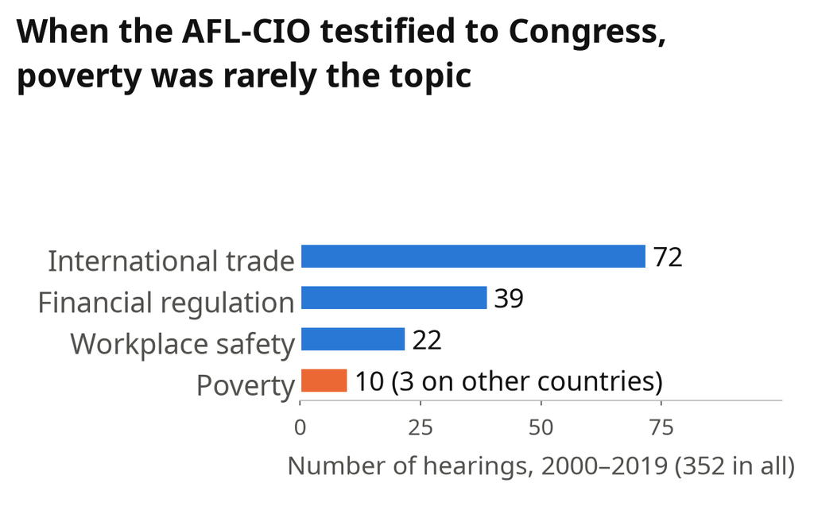

> **Why it matters:** Unions organize around the worker. Poor people without jobs, and programs for them like SSI or public housing, barely appear on labor’s agenda. **Use in your paper.**

*Source: Howard,* Who Cares*, ch. 2, “Organized Labor.”*

## Labor’s plan: prevent poverty with good jobs and social insurance

**What happened:** From 2001 to 2017, the AFL-CIO’s convention resolutions called for policies that help all workers and treated programs for the poor as an afterthought (“Organized Labor”).

- **Jobs:** full employment, and laws that make it easier to form a union.
- **A higher minimum wage:** $10.10 an hour in 2013, then $15 in 2017, defended as help for working and middle-class families.
- **Social insurance:** Medicare for everyone 55 and older, as a step toward a single government health plan. The 2013 report praised the ACA without mentioning its Medicaid expansion.
- **The exception:** SEIU, whose members are often low-paid, talks about “poverty wages” and about race and gender.

> **Why it matters:** Labor cares about the poor when their needs “dovetail with those of middle-class workers” (“Organized Labor”). If your program serves people who don’t work, don’t count on unions to defend it. **Use in your paper.**

*Source: Howard,* Who Cares*, ch. 2, “Organized Labor.”*

## Small-business owners worry about costs and taxes; poverty isn’t on their list

**What happened:** In 2016, the National Federation of Independent Business (NFIB) asked its members to rate 75 possible problems. Poverty, hunger, and homelessness were not among them (“Business Groups”).

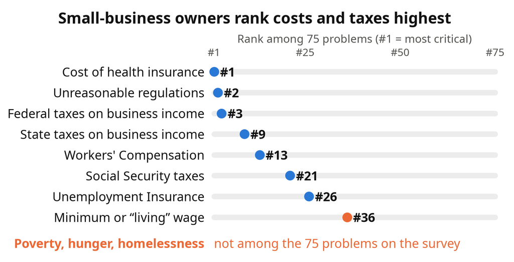

> **Why it matters:** To small business, social programs show up mainly as costs: taxes, insurance premiums, and mandates. The NFIB also sued to overturn the ACA and supports work requirements for Medicaid. **Use in your paper.**

*Source: Howard,* Who Cares*, ch. 2, “Business Groups,” (NFIB survey, Wade 2016). He gives #1 and #3 by number; regulations at #2 follows.*

## Big business talks about growth and the cost of entitlements

**What happened:** In ten annual speeches from 2010 to 2019, the head of the U.S. Chamber of Commerce mentioned poverty, poor people, or low income three times in more than 100 pages (“Business Groups”).

- **The Chamber’s view:** spending on Social Security and Medicare is “unsustainable.” Its answer for people left behind is education and job training.
- **The Business Roundtable,** the group of big-company CEOs, wants the retirement age raised to 70, plus a minimum Social Security benefit above the poverty line.
- **Its 2019 statement on corporate responsibility,** signed by nearly 200 CEOs, says nothing about the minimum wage, health insurance, or pensions.

> **Why it matters:** Big business mentions the poor mainly when arguing to cut or restructure entitlements. Expect it to oppose reforms paid for with higher taxes.

*Source: Howard,* Who Cares*, ch. 2, “Business Groups.”*

## Businesses that a program pays will defend it

**What happened:** Business groups split over the minimum wage and Medicaid, depending on whether a policy cost a firm money or brought money in (“Business Groups”).

- **The minimum wage:** when the House passed a $15 minimum in July 2019, the NFIB and the restaurant and retail associations opposed it. Amazon had already raised its own minimum pay to $15, Target had promised to by 2020, and McDonald’s had stopped lobbying against increases.
- **Medicaid expansion:** the NFIB fought it in court and in the states. Hospital associations backed it because Medicaid pays hospitals; Alabama’s said 75% of the state’s hospitals were losing money.

> **Why it matters:** A program that pays companies to deliver services gains business defenders. Howard: “Ironically,” business may care more about public assistance than labor does (“Discussion”). **Use in your paper.**

*Source: Howard,* Who Cares*, ch. 2, “Business Groups” and “Discussion.”*

## Desmond ch. 6: better-off Americans are leaving public services behind

**What happened:** In *Poverty, by America* (2023), sociologist Matthew Desmond argues that as better-off Americans grow richer, they buy private versions of schools, safety, and recreation and stop supporting the public ones (notes [6]–[7]).

- **An old name for it:** economist John Kenneth Galbraith called it “private opulence and public squalor” in 1958 (note [6]).
- **The result:** public schools, housing, and transit end up used mainly by the poor, which makes them easier to underfund (note [6]).
- **One example:** Michigan balanced its budget by canceling infrastructure work and firing safety inspectors, which fed the Flint water crisis; upward of 12,000 children were exposed to lead (note [8]).

> **Why it matters:** Desmond shifts the question from the poor to the comfortable. Poverty persists partly because better-off voters choose not to pay for what everyone shares.

*Source: Desmond 2023, ch. 6, notes [6]–[8].*

## Personal incomes grew faster than public money

**What happened:** Over the past fifty years, Americans’ personal incomes rose 317% while federal revenue rose 252%. From the first President Bush to President Trump, incomes in Oregon and Montana grew two to three times as fast as school spending (note [9]).

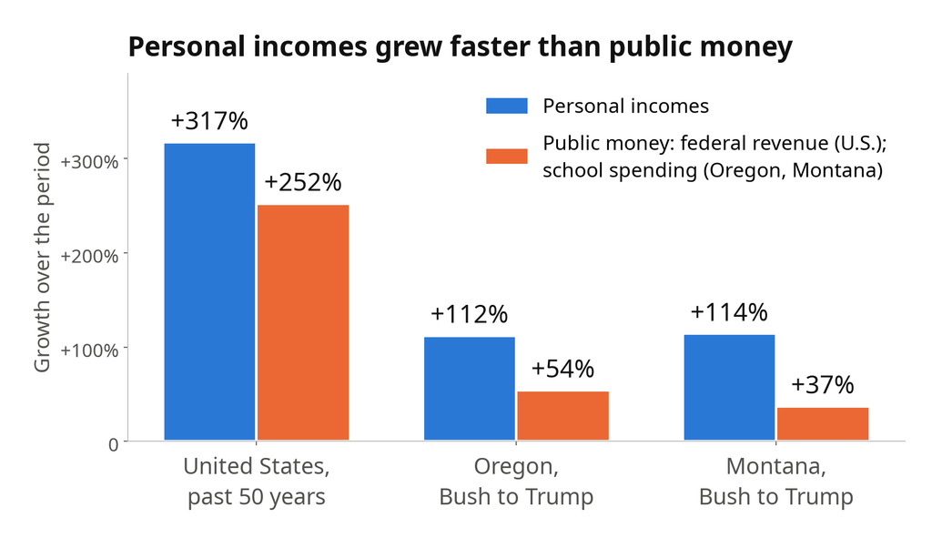

- By 2021, government spending on all public goods was 17.6% of the economy, while personal consumption had grown from about 60% to 69% (note [10]).

> **Why it matters:** Desmond finds this pattern in “red and blue states alike” (note [9]). You can’t pin it on one party. **Use in your paper.**

*Source: Desmond 2023, ch. 6, notes [9]–[10].*

## Tax revolts cut the money for public goods

**What happened:** Desmond traces the shift to tax cuts, starting with California’s Proposition 13 in the 1970s and President Reagan’s 1981 tax cut (notes [11]–[13]).

- **Proposition 13** capped California’s property taxes and passed with 65% of the vote. The state fell from first in school funding to ninth from the bottom (note [12]).
- **The 1981 tax cut (ERTA)** reduced federal revenue by more than 13% over four years. Reagan then cut the housing department’s budget by almost 70% (note [11]).
- **Who opposed Proposition 13:** only public-sector workers and African Americans. Desmond reads the tax revolts as white resistance to sharing public goods (note [13]).

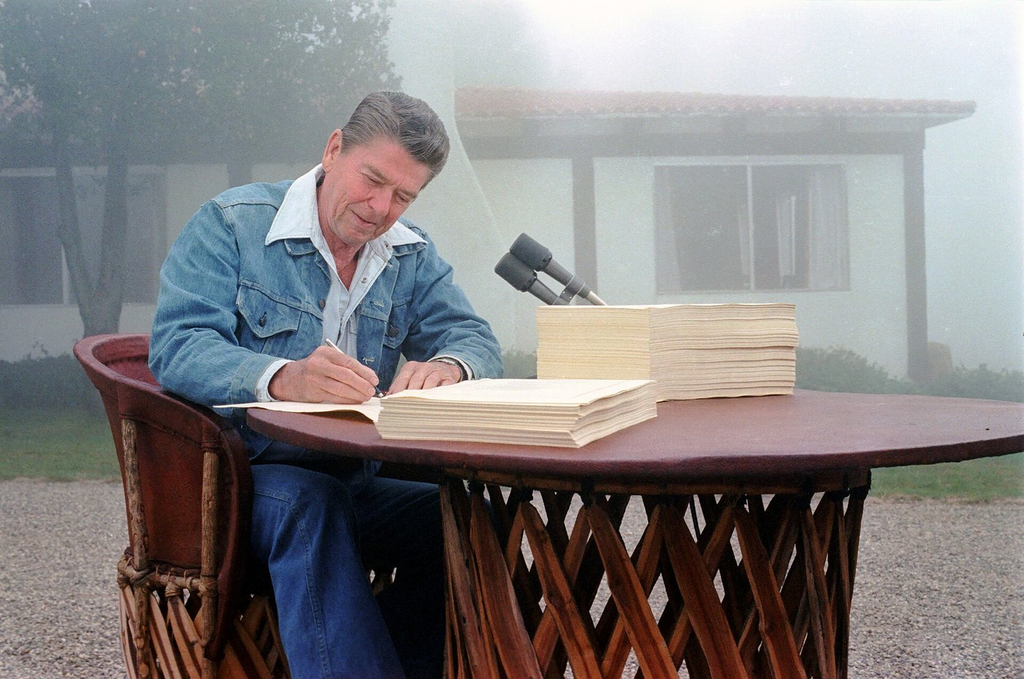

*Photo: Reagan signs the 1981 tax and budget bills at his ranch, August 13, 1981. Karl Schumacher, White House, public domain.*

> **Why it matters:** A tax cut is also a decision about public goods. When you name your reform’s obstacles, ask who would pay the taxes that fund it.

*Source: Desmond 2023, ch. 6, notes [11]–[13].*

## When public schools had to integrate, many white families left

**What happened:** After the civil rights rulings and laws of 1954 to 1968, many white families withdrew from integrated public spaces, then from whole cities, and took their tax dollars with them (note [14]).

- **The laws:** *Brown v. Board of Education* (1954) ended legal school segregation; the Civil Rights Act (1964) and the Fair Housing Act (1968) followed (note [14]).
- **Atlanta:** by the early 2000s, most of the city’s public schools had fewer than three white students (note [15]).
- **Historian Kevin Kruse:** the public world was “increasingly abandoned” to Black residents while whites built a private one (note [15]).

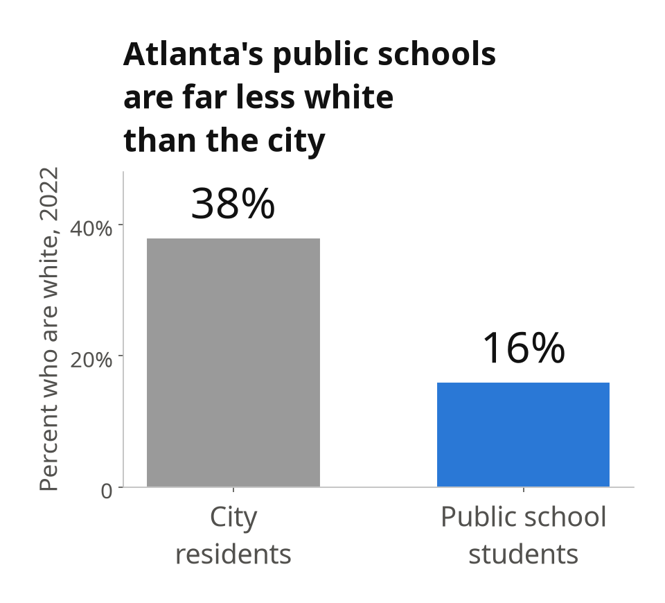

> **Why it matters:** Race shapes support for public spending, as Martin Gilens (Week 12) and Jamila Michener (Week 13) argued. Desmond adds the money trail: people who leave shared institutions stop paying for them. **Use in your paper.**

*Source: Desmond 2023, ch. 6, notes [14]–[15].*

## Zoning laws keep lower-income families out of better-off neighborhoods

**What happened:** Local zoning rules decide what can be built. In many U.S. cities, most residential land is reserved for single-family houses, which keeps out apartments and the families who rent them (notes [21]–[22]).

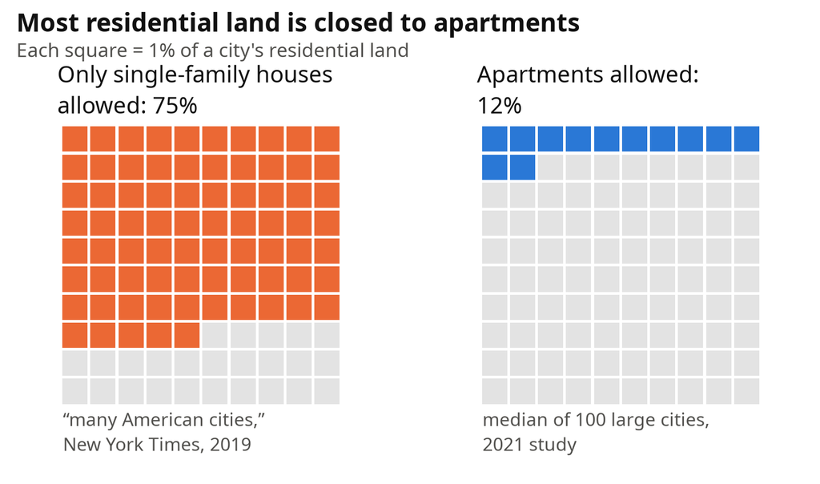

- After the Supreme Court outlawed openly racial zoning, Atlanta renamed its “R-1 white district” the “R-1 dwelling house district” (note [21]).
- In one study, conservative renters were more willing than liberal homeowners to accept a 120-unit apartment building nearby (note [24]).

> **Why it matters:** Keeping opportunity for yourself takes no lobby: homeowners’ votes and local zoning do the work. Desmond notes that progressive cities built “the highest walls” (note [23]). **Use in your paper.**

*Source: Desmond 2023, ch. 6, notes [21]–[24].*

## Desmond: sharing opportunity will cost the comfortable something

**What happened:** Desmond ends the chapter by rejecting the “everybody wins” pitch, the claim that integration and anti-poverty policy cost better-off people nothing (notes [25]–[29]).

- **What’s at stake for children:** one study found that growing up in a severely disadvantaged neighborhood harms verbal ability as much as missing a year of school (note [28]).
- **Who holds on:** sociologist Tressie McMillan Cottom: “The families that can hoard do” (note [29]).
- **Desmond’s conclusion:** those who have gained must “take less so that others may share” (note [29]).

> **Why it matters:** Your term paper has to name who loses from your reform. For reforms that share opportunity, Desmond’s answer is the comfortable. Say so plainly, then say what would have to be true for the reform to pass anyway.

*Source: Desmond 2023, ch. 6, notes [25]–[29].*

## Monday’s deck in one slide: Howard, chapters 6 and 7

Monday’s deck walked Howard’s *The Welfare State Nobody Knows* (2007). Its two findings:

- **Chapter 6, public opinion:** Americans support Social Security, Medicare, and spending on health and schools nearly as much as Europeans do, and in 1996 most chose more social spending over a tax cut. When Americans distrusted Washington, Congress used tax breaks and rules on employers instead of new programs (pp. 113–24).
- **Chapter 7, the elderly:** AARP, the big seniors’ lobby, arrived after most programs were built, blocks some cuts, and rarely wins new benefits. Younger adults back programs for the elderly as much as older adults do (pp. 128–48).
- **The thread through both:** about a quarter of Social Security and Medicare recipients vote on their program, compared with about 10% of people on welfare, food stamps, or Medicaid (p. 144). Programs for everyone build defenders; programs for the poor mostly don’t.

## Four readings, one question: who pushes, and for whom?

| Reading | Who pushes | For whom | The key evidence |
| --- | --- | --- | --- |
| **Howard, ch. 6** | The public, broadly | The old and sick first; the unemployed and “welfare” last | Surveys from 1996 and 2002; trust and policy tools (pp. 113–24) |
| **Howard, ch. 7** | Seniors defend programs; political leaders build them | Retirees, with younger adults’ support | AARP’s record; voting by age; part D (pp. 128–48) |
| *Who Cares*, ch. 2 | Unions push for workers; business for lower costs | The middle class; the poor only when they overlap | Resolutions, speeches, surveys; hospitals and Medicaid |
| **Desmond, ch. 6** | Better-off voters and homeowners | Themselves: they buy opportunity and wall it off | Tax revolts, school segregation, zoning (notes [9]–[29]) |

> **Why it matters:** In all four readings, almost no one organizes for poor people who don’t work. Programs for everyone build defenders (voters, AARP, hospitals paid by Medicaid); programs only for the poor build few, and the comfortable can opt out of public goods entirely.

## Checklist for your term paper (due today, 11:59 p.m.)

The rubric gives 30% to using course concepts to explain why your program’s problem persists, and 15% to its political obstacles: who loses and who blocks. Ask these questions about your program:

1. **Do its recipients vote on it?** Programs for everyone create voters; programs for the poor mostly don’t (Howard 2007, p. 144).
2. **Which organized groups defend it?** Seniors’ groups defend more than they build (pp. 129–37); unions speak for workers (*Who Cares*, ch. 2, “Organized Labor”).
3. **Who gets paid to deliver it?** Hospitals defend Medicaid; small business opposes it (*Who Cares*, ch. 2, “Business Groups”).
4. **What does the public say about it?** Strong support for the old and sick, weak for “welfare” and the unemployed (Howard 2007, pp. 113–19).
5. **What policy tool does your reform use,** and does today’s trust in government allow it (pp. 122–24)?
6. **Who would have to give something up?** (Desmond, ch. 6, note [29])

*Optional: PapyrusAI’s Term Paper Dialectical Partner will argue against your proposal. Disclose any AI use.*